# Sampling for Posterior Inference

# Summarizing a posterior distribution

Often we want to know something about some parameter $\theta$

- What is the probability that $\theta$ is less than some value—e.g., $pr(b \le 0)$
- What is the probability that $\theta$ is between two particular values
- What interval encompasses 90% or 95% of the probability mass? **90% Credible Interval**

```r
t(apply(multi_sample, 2, quantile, c(0.05, 0.95)))
##            5%     95%
## a     -2.2728 -0.8172
## b      0.9149  1.1453
## log_s -0.8929 -0.6608
```

# Summarizing a posterior distribution

Often we want to know something about some parameter $\theta$

- What is the probability that $\theta$ is less than some value—e.g., $pr(b \le 0)$
- What is the probability that $\theta$ is between two particular values
- What interval encompasses 90% or 95% of the probability mass? **90% Credible Interval**
- What is the most likely value or “best” guess of theta?

```r
mn = colMeans(as.matrix(multi_sample))
med = apply(as.matrix(multi_sample), 2, median)
tab = matrix(c(mn, med, fit$par), ncol=3, byrow=TRUE, dimnames = list(c("mean", "median", "mode"), names(fit$par)))
```

|  | a | b | log_s |
| --- | --- | --- | --- |
| mean | -1.549 | 1.031 | -0.7782 |
| median | -1.551 | 1.031 | -0.7788 |
| mode | -1.551 | 1.031 | -0.7769 |

- MAP estimates the posterior mode.
- For normal distribution, mode, mean, median all the same.
- In other cases, median performs best

# Posterior prediction

- Posterior distributions are *transitive*

> If $\hat{\theta}$ is a set of samples approximating the posterior distribution of $\theta$, and if some desired variable $Z = f(\theta)$, then $f(\hat{\theta})$ approximates the posterior distribution of $Z$
- We can use this to get a posterior distribution of **regression lines**

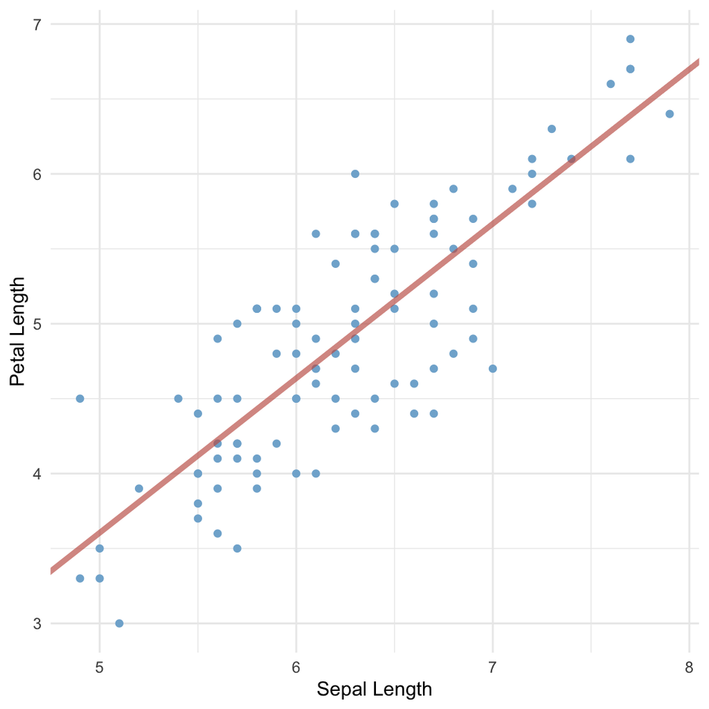

```
## MLE: a = -1.55; b = 1.03
```

# Posterior prediction

- Posterior distributions are *transitive*

> If $\hat{\theta}$ is a set of samples approximating the posterior distribution of $\theta$, and if some desired variable $Z = f(\theta)$, then $f(\hat{\theta})$ approximates the posterior distribution of $Z$
- We can use this to get a posterior distribution of **regression lines**

```r
## choose one random row number
i = sample(nrow(multi_sample), 1)
## extract that slope and intercept
samp = multi_sample[i, ]
```

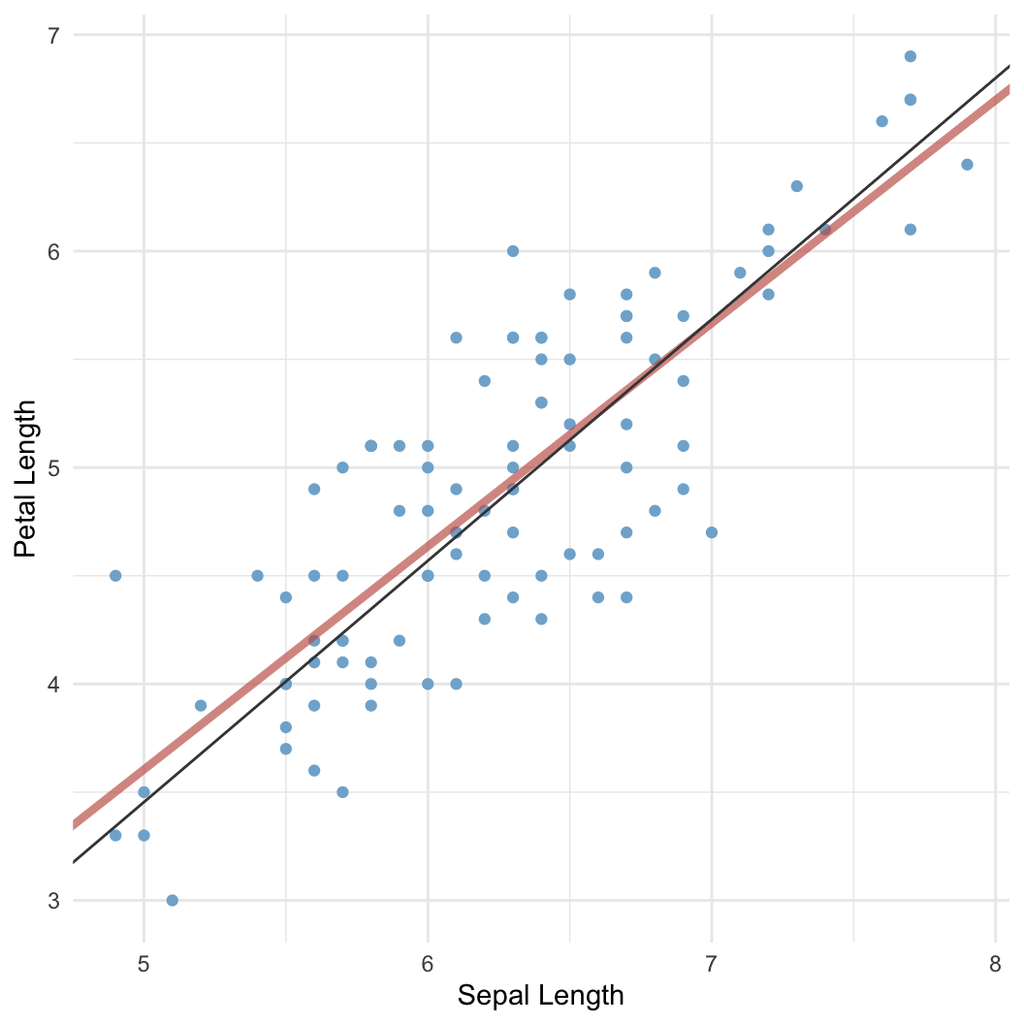

```
## Sample 1: a = -2.12; b = 1.12
```

# Posterior prediction

- Posterior distributions are *transitive*

> If $\hat{\theta}$ is a set of samples approximating the posterior distribution of $\theta$, and if some desired variable $Z = f(\theta)$, then $f(\hat{\theta})$ approximates the posterior distribution of $Z$
- We can use this to get a posterior distribution of **regression lines**

```r
## choose one random row number
i = sample(nrow(multi_sample), 1)
## extract that slope and intercept
samp = multi_sample[i, ]
```

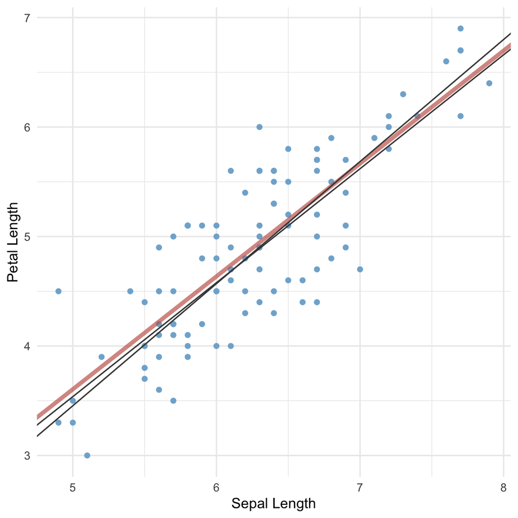

```
## Sample 2: a = -1.67; b = 1.04
```

# Posterior prediction

- Posterior distributions are *transitive*

> If $\hat{\theta}$ is a set of samples approximating the posterior distribution of $\theta$, and if some desired variable $Z = f(\theta)$, then $f(\hat{\theta})$ approximates the posterior distribution of $Z$
- We can use this to get a posterior distribution of **regression lines**

```r
## choose one random row number
i = sample(nrow(multi_sample), 1)
## extract that slope and intercept
samp = multi_sample[i, ]
```

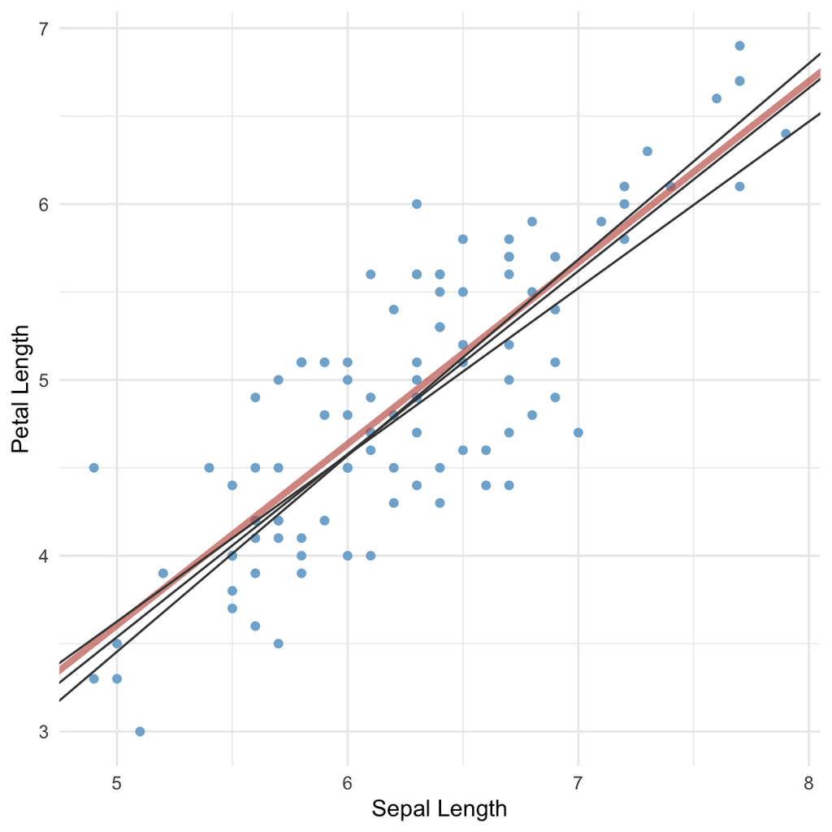

```
## Sample 3: a = -1.11; b = 0.95
```

# Posterior prediction

- Posterior distributions are *transitive*

> If $\hat{\theta}$ is a set of samples approximating the posterior distribution of $\theta$, and if some desired variable $Z = f(\theta)$, then $f(\hat{\theta})$ approximates the posterior distribution of $Z$
- We can use this to get a posterior distribution of **regression lines**

```r
# take 100 samples
i = sample(nrow(multi_sample), 100)
samp = multi_sample[i, ]
```

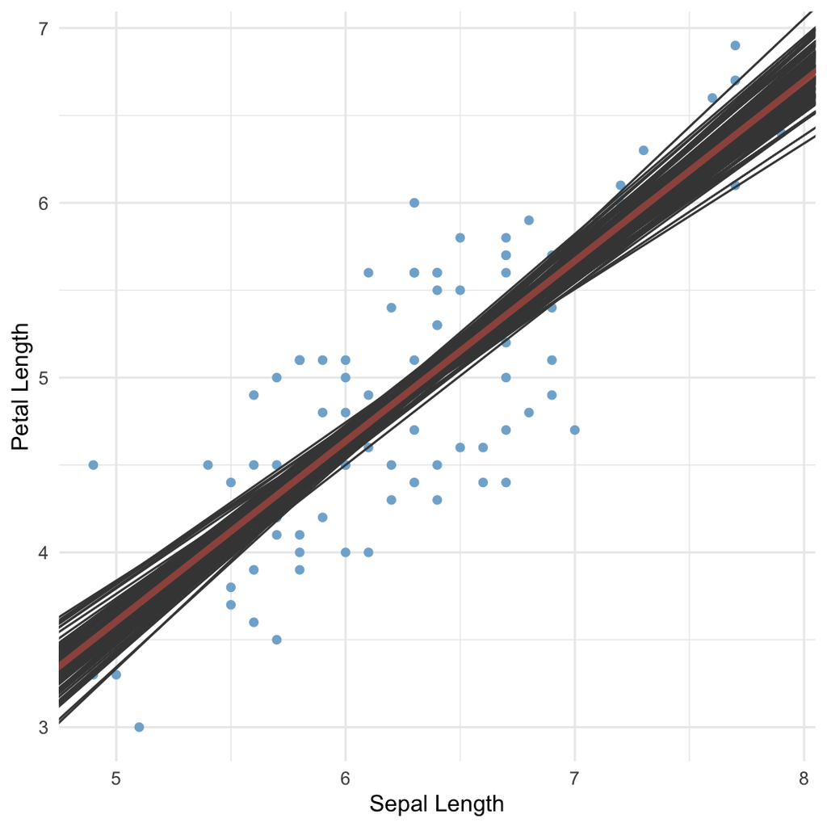

```
##           a      b   log_s
## 5027 -1.879 1.0824 -0.8543
## 4670 -1.911 1.0864 -0.8631
## 9043 -1.497 1.0195 -0.8101
## 5054 -2.103 1.1175 -0.6532
## 5356 -1.430 1.0263 -0.8124
## 5675 -1.259 0.9904 -0.8052
```